# Intratumoral T-cell and B-cell receptor architecture associates with distinct immune tumor microenvironment features and clinical outcomes of anti-PD-1/L1 immunotherapy

¶ Uni and Multivariate survival analysis for anti-PD(L)1 public and restricted data ¶

Aimilia Schina

First created on 9 October 2019. Updated on 20 February 2024

```r
## Clear R-workspace
# rm(list=ls(all=TRUE))

## Close all graphic devices
graphics.off()
#####################
### Load packages ###
#####################
library(pacman)

pacman::p_load(extrafont,DT,dplyr,tibble,survminer,survival, ggplot2, hrbrthemes, grid, gridExtra, cowplot,Amelia,data.table, tidytidbits,survivalAnalysis,gtsummary,purrr,plyr, pmsampsize,boot,pec,mosaic,boot.pval, stringr)

extrafont::loadfonts(device="win")
windowsFonts(sans="Palatino Linotype")
loadfonts(device="win")
loadfonts(device="postscript")
```

```r
###########################
### Main analysis paths ###
###########################
# Main
scriptsPath <- paste0("scripts/")
scriptsMainPath<- paste0(scriptsPath, "main/")
scriptsFunctionsPath <- paste0(scriptsPath,"functions/")
projectDataPath <- paste0("data/")
# Input
tcgaInputData <- paste0(projectDataPath,"TCGA/")
antiPDL1publicInputData <- paste0(projectDataPath,"antiPD(L)1_public/")
otherInputData <- paste0(projectDataPath,"other/")
referenceInputData <- paste0(projectDataPath,"reference/")
# Output
projectOutDataPath <- paste0("output/data_files/")
# tcgaIntermediateData <- paste0(projectOutDataPath,"TCGA/")
antiPDL1publicIntermediateData <- paste0(projectOutDataPath,"antiPD(L)1_public/")

# Session/dependencies
sessionInfoPath <- paste0("session_info/")

######################################
## Create intermediate output paths ##
######################################
if (!dir.exists(paste0(projectOutDataPath,"survival/"))) {dir.create(paste0(projectOutDataPath,"survival/"))}


##################################
### LOAD SOURCE FUNCTIONS FILE ###
##################################
source(paste0(scriptsFunctionsPath,"aPD1_survival_analysis_functions.R"), local=T)

#####################
### File suffixes ###
#####################
Rdata.suffix <- ".RData"

######################
### Model variables ###
######################

modelTypeA <- "_TCRArichnessIGH.ds"
modelTypeB <- "_noLIU"
modelTypeC <- "_mintcr4bcr10"
```

# 1 Loading Sample and Clone data

We are using the data that were TCRa min 4 clones, BCR igh min 10 clones

```r
immdata.TcrBcr.full.red <- loadRData(paste0(antiPDL1publicIntermediateData,"immdata.TcrBcr.full.red",modelTypeA,modelTypeB,modelTypeC,".RData"))
immdata.TcrBcr.full.red$response <- ifelse(immdata.TcrBcr.full.red$response=="CR+PR","CRPR",immdata.TcrBcr.full.red$response)
```

We are keeping all samples, irrespective of response, since we are doing survival analysis

```r
table(immdata.TcrBcr.full.red$response)
```

```
##
## CRPR   MR   NE   PD   SD  UNK
##  196    2   45  323  128    1
```

```r
datatable(immdata.TcrBcr.full.red %>% dplyr::select(run_accession,response,tissue) %>% group_by(tissue,response) %>% dplyr::summarise(no_rows=length(response)), extensions = 'Buttons', options = list(
    dom = 'Bfrtip',
    buttons = c('copy', 'excel', 'csv' ),
    scrollX=TRUE,
    pageLength=15
  ),
  caption = 'Number of responders/non-responders in all tissues'
)
```

|  | tissue | response | no_rows |
| --- | --- | --- | --- |
| 1 | bladder | CRPR | 77 |
| 2 | bladder | NE | 43 |
| 3 | bladder | PD | 171 |
| 4 | bladder | SD | 53 |
| 5 | gastric | CRPR | 12 |
| 6 | gastric | PD | 17 |
| 7 | gastric | SD | 14 |
| 8 | melanoma | CRPR | 87 |
| 9 | melanoma | MR | 2 |
| 10 | melanoma | PD | 103 |

[output cut: 6 more lines]

```r
datatable(immdata.TcrBcr.full.red %>% dplyr::filter(complete.cases(TMB)) %>% dplyr::select(run_accession,response,tissue) %>% group_by(tissue,response) %>% dplyr::summarise(no_rows=length(response)), extensions = 'Buttons', options = list(
    dom = 'Bfrtip',
    buttons = c('copy', 'excel', 'csv' ),
    scrollX=TRUE,
    pageLength=15
  ),
  caption = 'Number of responders/non-responders in all tissues that have TMB'
)
```

|  | tissue | response | no_rows |
| --- | --- | --- | --- |
| 1 | bladder | CRPR | 71 |
| 2 | bladder | NE | 33 |
| 3 | bladder | PD | 144 |
| 4 | bladder | SD | 38 |
| 5 | melanoma | CRPR | 58 |
| 6 | melanoma | MR | 2 |
| 7 | melanoma | PD | 69 |
| 8 | melanoma | SD | 22 |
| 9 | melanoma | UNK | 1 |
| 10 | RCC | CRPR | 12 |

[output cut: 3 more lines]

Preparing other variables and dataframes necessary for the analysis.

```r
## EXTRACT RESPONSE, NOMINAL, MEASURE VARIABLES FROM DATA
response.var <- "response"
nominal.vars <- c("dataset","tissue","gender")
measure.vars <-colnames(immdata.TcrBcr.full.red)[c(2:10,12,32:43)]
measure.vars <- measure.vars[c(6,22,1:3,20,21,4:5,10,7:9,11:19)]


## CHECK INFINITE LOG TMB VALUES
immdata.TcrBcr.full.red[which(is.infinite(immdata.TcrBcr.full.red$logTMB)),]
```

```
##  [1] run_accession      TuTACK_sigscore    TIS_sigscore       PDL1               CD8A               CD8B               TCRArichness.ds
##  [8] StromalScore       ImmuneScore        ESTIMATEScore      title              age                gender             disease_status
## [15] biopsy_site        primary_tumor      treatment          prior_treatment    response           OS.time            OS
## [22] PFS.time           PFS                pre_on_treatment   total_muts         nonsyn_muts        clonal_muts        subclonal_muts
## [29] TMB                tissue             dataset            Bcells             CD8cells           CD4cells           Tregs
## [36] NKcells            DCcells            Monocytes          Granulocytes       Macrophages        TumorPurity        logTMB
## [43] BCR.IGHrichness.ds
## <0 rows> (or 0-length row.names)
```

```r
## Extract tissues in data so far
tissues <- unique(immdata.TcrBcr.full.red$tissue)

# Which are the covariates I am considering
covariatesIn <- measure.vars[c(1:2,4:7,14:16)]
responseVar <- "response"


## DATA TO WORK WITH
#
# immdata.TcrBcr.ALL.ready <- immdata.TcrBcr.full.red.sub.filt %>% dplyr::filter(dataset %notin% c("Liu") ) %>% droplevels() # All tissues, PD, CR, PR, complete data
```

# 2 Data Exploration

**TOTAL available data**

```r
nrow(immdata.TcrBcr.full.red)
```

[1] 695

**Table of available data per dataset**

```r
table(immdata.TcrBcr.full.red$dataset)
```

```
   Gide        Hugo Immotion150         Kim         Liu        Mari        Miao      Powles        Riaz         Rod
     38          28          60          43          89         276          28          68          38          27
```

**Table of available data per tissue**

```r
table(immdata.TcrBcr.full.red$tissue)
```

bladder gastric melanoma RCC 344 43 220 88

```r
mycancertypes.final <-unique(immdata.TcrBcr.full.red$tissue)
mycancertypes.final <- mycancertypes.final[c(2,4,1,3)]
# parameters <- colnames(immdata.TcrBcr.full.red.sub)[c(4,42,43,32,33,34,3,41)]
# labels <- c("PD-L1 expression","logTMB","BCR Richness","B cells infiltration","CD8+ T cells infilitration","CD4+ T cells infilitration",
#             "T-cell inflamed GEP", "Tumor Purity")
```

```r
colnames(immdata.TcrBcr.full.red)[c(7,43,32,4)] <- c("TCR_Richness","BCR_Richness","B_cells","PD_L1")
featuresIn <- colnames(immdata.TcrBcr.full.red)[c(4,42,43,7,32,33,34,3,41)]
featuresInLabels <- c("PD-L1 expression","logTMB","BCR Richness","TCR Richness","B cells infiltration","CD8+ T cells infiltration","CD4+ T cells infiltration",
            "T-cell inflamed GEP", "Tumor Purity")

tissues<- unique(immdata.TcrBcr.full.red$tissue)
tissues <- tissues[c(2,4,1,3)]
```

Select rows (patient IDs) for which we have all data:

- TCR richness, from immune pancancer data not clone data
- BCR richness
- Immune infiltration from DanaherZ CIBERSORT : B cells, CD8 T cells, CD4 T cells
- TMB only for TP data not NT
- GEP,
- PD-L1 (not TuTack since it’s not main part of analysis)
- Tumor Purity (ESTIMATE)
- Survival data, OS OS.time

```r
featuresSelected <- c("run_accession", "tissue","PD_L1","logTMB","BCR_Richness","TCR_Richness",
                      "B_cells", "CD8cells", "CD4cells","TIS_sigscore", "TumorPurity","OS","OS.time","PFS","PFS.time","age","gender")

extraFeatures <- c("StromalScore", "ImmuneScore")

featuresIn <- c("TCR_Richness","BCR_Richness","logTMB","PD_L1","TIS_sigscore",
                      "CD8cells", "CD4cells","B_cells",  "TumorPurity")
featuresInLabels <- c("TCR Richness","BCR Richness","logTMB","PD-L1 expression","T-cell inflamed GEP", "CD8+ T cells infiltration","CD4+ T cells infiltration","B cells infiltration",
            "Tumor Purity")
## FOR TP data
immdata.TcrBcr.full.red.sub <- immdata.TcrBcr.full.red %>% dplyr::select(all_of(featuresSelected)) %>% droplevels() %>% distinct()
immdata.TcrBcr.full.red.sub.extra <- immdata.TcrBcr.full.red %>% dplyr::select(all_of(c(featuresSelected,extraFeatures))) %>% droplevels() %>% distinct()

# Keep rows where at least on of the features of interested is not NA
dim(immdata.TcrBcr.full.red.sub)
```

```
## [1] 695  17
```

```r
immdata.TcrBcr.full.red.sub <-immdata.TcrBcr.full.red.sub[rowSums(is.na(immdata.TcrBcr.full.red.sub[,3:11])) != 9,]
dim(immdata.TcrBcr.full.red.sub)
```

```
## [1] 695  17
```

```r
dim(immdata.TcrBcr.full.red.sub.extra)
```

```
## [1] 695  19
```

```r
immdata.TcrBcr.full.red.sub.extra <-immdata.TcrBcr.full.red.sub.extra[rowSums(is.na(immdata.TcrBcr.full.red.sub.extra[,3:11])) != 9,]
dim(immdata.TcrBcr.full.red.sub.extra)
```

```
## [1] 695  19
```

```r
# There is a duplicated patient
```

Look again at missing values

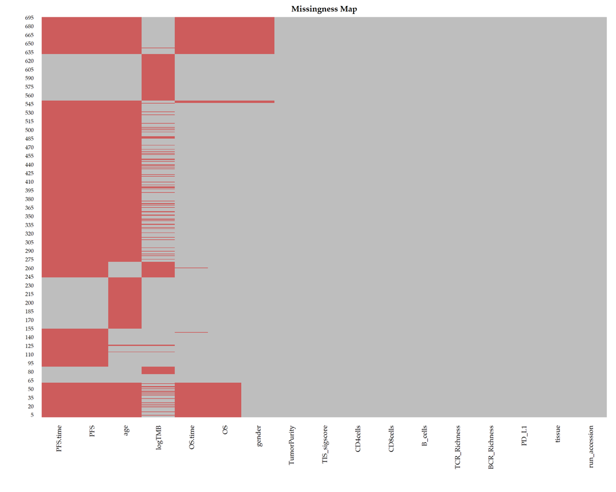

```r
visDF <- immdata.TcrBcr.full.red.sub

missmap(visDF, col=c("Indian red", "grey"), legend=FALSE,x.cex=1,margins=c(9,5))
```

We are not using complete data function since we see that depending on the feature, lots of data are missing.

```r
# Let's summarize the TCGA biospecimen data we just loaded
# Number of patients per project
immdata.TcrBcr.full.red.sub.table <-immdata.TcrBcr.full.red.sub %>% dplyr::select(tissue,run_accession) %>% group_by(tissue) %>% distinct() %>% dplyr::summarize(n())
```

- THYM
- DLBC
- COAD MSI low
- BRCA Her2
- BRCA Luminal A
- BRCA Luminal B
- BRCA
- BRCA Normal
- COAD

Eventually we are also excluding KIRP (papillary).

```r
#mycancertypes.final
#tissues

# Make project a factor with levels
immdata.TcrBcr.full.red.sub$tissue <- factor(immdata.TcrBcr.full.red.sub$tissue, levels=mycancertypes.final)
immdata.TcrBcr.full.red.sub.extra$tissue <- factor(immdata.TcrBcr.full.red.sub.extra$tissue, levels=mycancertypes.final)
```

```r
datatable(immdata.TcrBcr.full.red.sub.table, extensions = 'Buttons', options = list(
    dom = 'Bfrtip',
    buttons = c('copy', 'excel', 'csv' ),
    scrollX=TRUE,
    pageLength=15
  ),
  caption = 'Number of patients per tissue'
)
```

|  | tissue | n() |
| --- | --- | --- |
| 1 | bladder | 344 |
| 2 | gastric | 43 |
| 3 | melanoma | 220 |
| 4 | RCC | 88 |